# 09_calculate_z_from_sample_mean

## 09_calculate_z_from_sample_mean

#### Question

1. This question provides $\mu$, $\sigma$, $n$, and $\bar{x}$. You will characterize the [sampling distribution](https://en.wikipedia.org/wiki/Sampling_distribution) by finding the [standard error](https://en.wikipedia.org/wiki/Standard_error), calculate the [standard score](https://en.wikipedia.org/wiki/Standard_score), determine the [percentile rank](https://en.wikipedia.org/wiki/Percentile_rank) (expressed as a decimal), and translate the score into a rating (see below).

### Population

   When Archie practices archery, each arrow has the same probability distribution (see [i.i.d](https://en.wikipedia.org/wiki/Independent_and_identically_distributed_random_variables)). This means her skill is constant, there is no [hot-hand effect](https://en.wikipedia.org/wiki/Hot_hand), and there is no [maturity of chances](https://en.wikipedia.org/wiki/Gambler%27s_fallacy).

   Over many months, Archie has shot ten thousand arrows (their positions are shown below as dots).

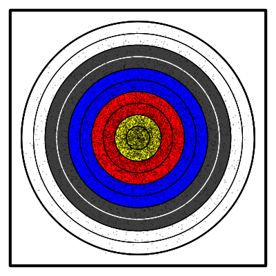

   From those many arrows, Archie has determined an accurate probability distribution (of the points scored by an arrow).

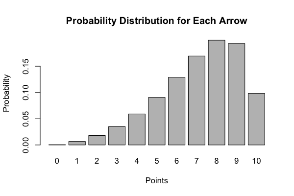

   Archie has determined her arrows’ population mean and population standard deviation.
   $$\mu=7.12$$
   $$\sigma=2.04$$

## Sampling distribution

   Each day, Archie shoots 96 arrows ($n=96$) and determines that day’s mean score. A mean of 10 would be a perfect day. We can treat each day’s mean as a random variable with its own probability distribution: a [sampling distribution](https://en.wikipedia.org/wiki/Sampling_distribution). We wish to characterize this sampling distribution. From the [central limit theorem](https://en.wikipedia.org/wiki/Central_limit_theorem), we know the sampling distribution is approximately normal; however, we need to calculate the parameters: the mean and the standard error.

### Mean of the sampling distribution

   The sampling distribution’s mean is simply equal to the population mean.
   $$\text{expected mean} = \mu$$
   - What is the sampling distribution’s mean?

### Standard error (standard deviation of sampling distribution)

   The standard error of a mean is the quotient of the population standard deviation and the square root of the sample size.
   $$\text{standard error of mean} = \frac{\sigma}{\sqrt{n}}$$
   This standard error is the standard deviation of the sampling distribution.
   - What is the standard error of the sampling distribution?

### Sample

   Today, Archie’s mean score is 7.073 points ($\bar{x} = 7.073$).

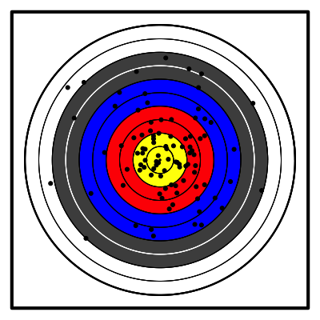

### Standard score

   Archie would like to know how well she did today. She wants you to calculate a standard score (a $z$ score). To calculate the standard score of a sample mean, you can use the following formula.
   $$z = \frac{\bar x - \mu}{\sigma/\sqrt{n}}$$
   - What is the $z$ score?

### Cumulative probability (percentile rank)

   Archie would like to know the probability that tomorrow she shoots worse than today. To estimate this, report the cumulative probability associated with the $z$-score you calculated. This can be done with a [$z$ table](https://en.wikipedia.org/wiki/Standard_normal_table#Conversion), `pnorm` function in R, `NORM.DIST` function in a spreadsheet, or with other standard normal tools.

   Remember, since we are using a $z$ score, the normal distribution parameters are mean=0 and sd=1.
   - What is the probability that Archie shoots worse tomorrow?

### Rating

   Archie would like a rating for her day’s performance. You decide to use the following scale and that if $z$ is on a boundary, Archie will be given the higher rating.

   | $z$ interval | rating |
   | --- | --- |
   | $-\infty$ to -1.51 | F |
   | -1.5 to -0.51 | D |
   | -0.5 to 0.49 | C |
   | 0.5 to 1.49 | B |
   | 1.5 to $\infty$ | A |

   - Determine Archie’s rating:

#### Solution

#### Question

2. This question provides $\mu$, $\sigma$, $n$, and $\bar{x}$. You will characterize the [sampling distribution](https://en.wikipedia.org/wiki/Sampling_distribution) by finding the [standard error](https://en.wikipedia.org/wiki/Standard_error), calculate the [standard score](https://en.wikipedia.org/wiki/Standard_score), determine the [percentile rank](https://en.wikipedia.org/wiki/Percentile_rank) (expressed as a decimal), and translate the score into a rating (see below).

### Population

   When Archie practices archery, each arrow has the same probability distribution (see [i.i.d](https://en.wikipedia.org/wiki/Independent_and_identically_distributed_random_variables)). This means her skill is constant, there is no [hot-hand effect](https://en.wikipedia.org/wiki/Hot_hand), and there is no [maturity of chances](https://en.wikipedia.org/wiki/Gambler%27s_fallacy).

   Over many months, Archie has shot ten thousand arrows (their positions are shown below as dots).

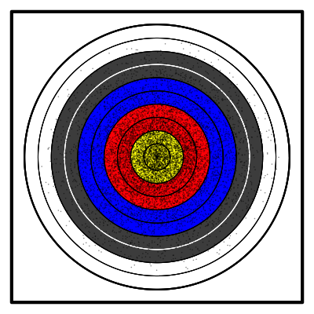

   From those many arrows, Archie has determined an accurate probability distribution (of the points scored by an arrow).

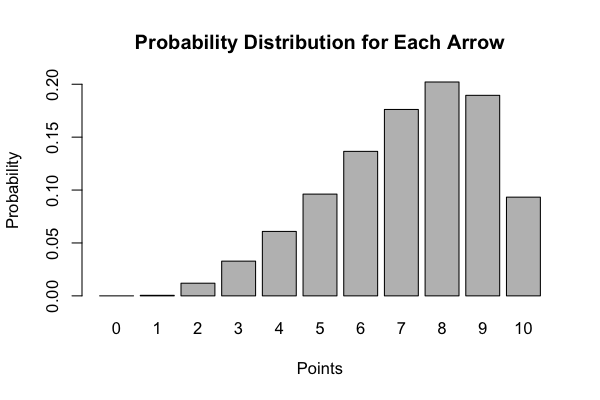

   Archie has determined her arrows’ population mean and population standard deviation.
   $$\mu=7.16$$
   $$\sigma=1.92$$

## Sampling distribution

   Each day, Archie shoots 144 arrows ($n=144$) and determines that day’s mean score. A mean of 10 would be a perfect day. We can treat each day’s mean as a random variable with its own probability distribution: a [sampling distribution](https://en.wikipedia.org/wiki/Sampling_distribution). We wish to characterize this sampling distribution. From the [central limit theorem](https://en.wikipedia.org/wiki/Central_limit_theorem), we know the sampling distribution is approximately normal; however, we need to calculate the parameters: the mean and the standard error.

### Mean of the sampling distribution

   The sampling distribution’s mean is simply equal to the population mean.
   $$\text{expected mean} = \mu$$
   - What is the sampling distribution’s mean?

### Standard error (standard deviation of sampling distribution)

   The standard error of a mean is the quotient of the population standard deviation and the square root of the sample size.
   $$\text{standard error of mean} = \frac{\sigma}{\sqrt{n}}$$
   This standard error is the standard deviation of the sampling distribution.
   - What is the standard error of the sampling distribution?

### Sample

   Today, Archie’s mean score is 6.792 points ($\bar{x} = 6.792$).

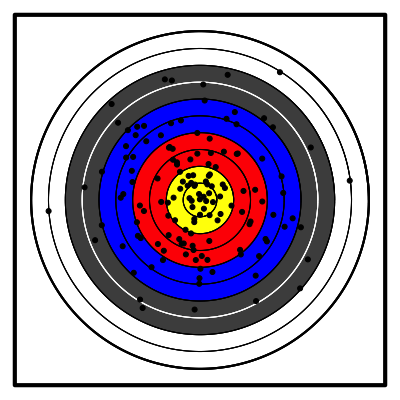

### Standard score

   Archie would like to know how well she did today. She wants you to calculate a standard score (a $z$ score). To calculate the standard score of a sample mean, you can use the following formula.
   $$z = \frac{\bar x - \mu}{\sigma/\sqrt{n}}$$
   - What is the $z$ score?

### Cumulative probability (percentile rank)

   Archie would like to know the probability that tomorrow she shoots worse than today. To estimate this, report the cumulative probability associated with the $z$-score you calculated. This can be done with a [$z$ table](https://en.wikipedia.org/wiki/Standard_normal_table#Conversion), `pnorm` function in R, `NORM.DIST` function in a spreadsheet, or with other standard normal tools.

   Remember, since we are using a $z$ score, the normal distribution parameters are mean=0 and sd=1.
   - What is the probability that Archie shoots worse tomorrow?

### Rating

   Archie would like a rating for her day’s performance. You decide to use the following scale and that if $z$ is on a boundary, Archie will be given the higher rating.

   | $z$ interval | rating |
   | --- | --- |
   | $-\infty$ to -1.51 | F |
   | -1.5 to -0.51 | D |
   | -0.5 to 0.49 | C |
   | 0.5 to 1.49 | B |
   | 1.5 to $\infty$ | A |

   - Determine Archie’s rating:

#### Solution

#### Question

3. This question provides $\mu$, $\sigma$, $n$, and $\bar{x}$. You will characterize the [sampling distribution](https://en.wikipedia.org/wiki/Sampling_distribution) by finding the [standard error](https://en.wikipedia.org/wiki/Standard_error), calculate the [standard score](https://en.wikipedia.org/wiki/Standard_score), determine the [percentile rank](https://en.wikipedia.org/wiki/Percentile_rank) (expressed as a decimal), and translate the score into a rating (see below).

### Population

   When Archie practices archery, each arrow has the same probability distribution (see [i.i.d](https://en.wikipedia.org/wiki/Independent_and_identically_distributed_random_variables)). This means her skill is constant, there is no [hot-hand effect](https://en.wikipedia.org/wiki/Hot_hand), and there is no [maturity of chances](https://en.wikipedia.org/wiki/Gambler%27s_fallacy).

   Over many months, Archie has shot ten thousand arrows (their positions are shown below as dots).

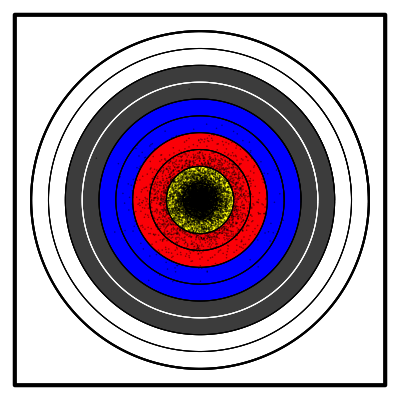

   From those many arrows, Archie has determined an accurate probability distribution (of the points scored by an arrow).

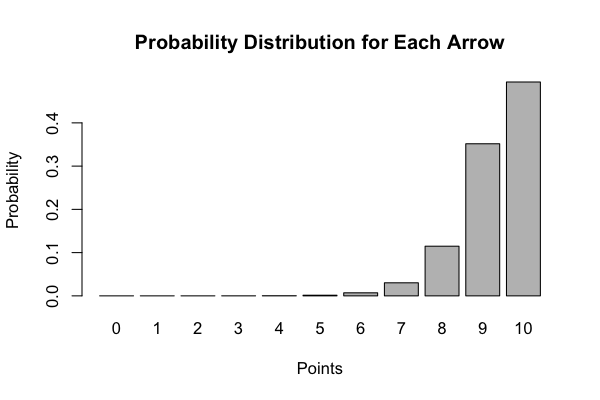

   Archie has determined her arrows’ population mean and population standard deviation.
   $$\mu=9.29$$
   $$\sigma=0.86$$

## Sampling distribution

   Each day, Archie shoots 132 arrows ($n=132$) and determines that day’s mean score. A mean of 10 would be a perfect day. We can treat each day’s mean as a random variable with its own probability distribution: a [sampling distribution](https://en.wikipedia.org/wiki/Sampling_distribution). We wish to characterize this sampling distribution. From the [central limit theorem](https://en.wikipedia.org/wiki/Central_limit_theorem), we know the sampling distribution is approximately normal; however, we need to calculate the parameters: the mean and the standard error.

### Mean of the sampling distribution

   The sampling distribution’s mean is simply equal to the population mean.
   $$\text{expected mean} = \mu$$
   - What is the sampling distribution’s mean?

### Standard error (standard deviation of sampling distribution)

   The standard error of a mean is the quotient of the population standard deviation and the square root of the sample size.
   $$\text{standard error of mean} = \frac{\sigma}{\sqrt{n}}$$
   This standard error is the standard deviation of the sampling distribution.
   - What is the standard error of the sampling distribution?

### Sample

   Today, Archie’s mean score is 9.053 points ($\bar{x} = 9.053$).

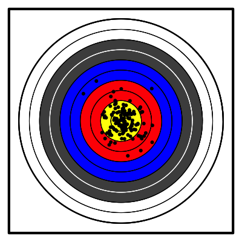

### Standard score

   Archie would like to know how well she did today. She wants you to calculate a standard score (a $z$ score). To calculate the standard score of a sample mean, you can use the following formula.
   $$z = \frac{\bar x - \mu}{\sigma/\sqrt{n}}$$
   - What is the $z$ score?

### Cumulative probability (percentile rank)

   Archie would like to know the probability that tomorrow she shoots worse than today. To estimate this, report the cumulative probability associated with the $z$-score you calculated. This can be done with a [$z$ table](https://en.wikipedia.org/wiki/Standard_normal_table#Conversion), `pnorm` function in R, `NORM.DIST` function in a spreadsheet, or with other standard normal tools.

   Remember, since we are using a $z$ score, the normal distribution parameters are mean=0 and sd=1.
   - What is the probability that Archie shoots worse tomorrow?

### Rating

   Archie would like a rating for her day’s performance. You decide to use the following scale and that if $z$ is on a boundary, Archie will be given the higher rating.

   | $z$ interval | rating |
   | --- | --- |
   | $-\infty$ to -1.51 | F |
   | -1.5 to -0.51 | D |
   | -0.5 to 0.49 | C |
   | 0.5 to 1.49 | B |
   | 1.5 to $\infty$ | A |

   - Determine Archie’s rating:

#### Solution

#### Question

4. This question provides $\mu$, $\sigma$, $n$, and $\bar{x}$. You will characterize the [sampling distribution](https://en.wikipedia.org/wiki/Sampling_distribution) by finding the [standard error](https://en.wikipedia.org/wiki/Standard_error), calculate the [standard score](https://en.wikipedia.org/wiki/Standard_score), determine the [percentile rank](https://en.wikipedia.org/wiki/Percentile_rank) (expressed as a decimal), and translate the score into a rating (see below).

### Population

   When Archie practices archery, each arrow has the same probability distribution (see [i.i.d](https://en.wikipedia.org/wiki/Independent_and_identically_distributed_random_variables)). This means her skill is constant, there is no [hot-hand effect](https://en.wikipedia.org/wiki/Hot_hand), and there is no [maturity of chances](https://en.wikipedia.org/wiki/Gambler%27s_fallacy).

   Over many months, Archie has shot ten thousand arrows (their positions are shown below as dots).

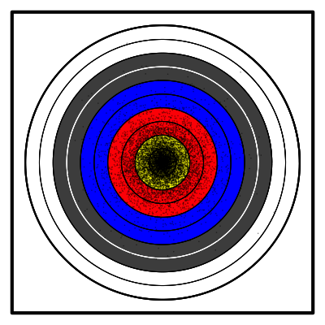

   From those many arrows, Archie has determined an accurate probability distribution (of the points scored by an arrow).

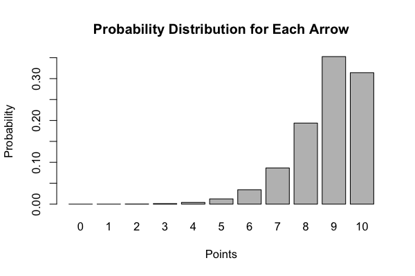

   Archie has determined her arrows’ population mean and population standard deviation.
   $$\mu=8.76$$
   $$\sigma=1.22$$

## Sampling distribution

   Each day, Archie shoots 120 arrows ($n=120$) and determines that day’s mean score. A mean of 10 would be a perfect day. We can treat each day’s mean as a random variable with its own probability distribution: a [sampling distribution](https://en.wikipedia.org/wiki/Sampling_distribution). We wish to characterize this sampling distribution. From the [central limit theorem](https://en.wikipedia.org/wiki/Central_limit_theorem), we know the sampling distribution is approximately normal; however, we need to calculate the parameters: the mean and the standard error.

### Mean of the sampling distribution

   The sampling distribution’s mean is simply equal to the population mean.
   $$\text{expected mean} = \mu$$
   - What is the sampling distribution’s mean?

### Standard error (standard deviation of sampling distribution)

   The standard error of a mean is the quotient of the population standard deviation and the square root of the sample size.
   $$\text{standard error of mean} = \frac{\sigma}{\sqrt{n}}$$
   This standard error is the standard deviation of the sampling distribution.
   - What is the standard error of the sampling distribution?

### Sample

   Today, Archie’s mean score is 8.742 points ($\bar{x} = 8.742$).

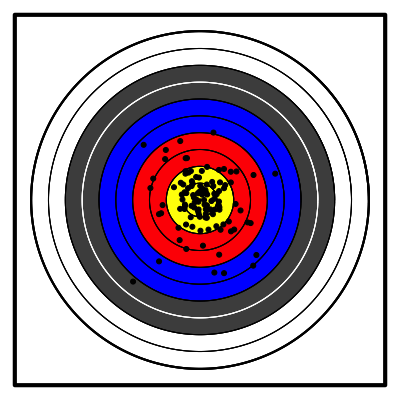

### Standard score

   Archie would like to know how well she did today. She wants you to calculate a standard score (a $z$ score). To calculate the standard score of a sample mean, you can use the following formula.
   $$z = \frac{\bar x - \mu}{\sigma/\sqrt{n}}$$
   - What is the $z$ score?

### Cumulative probability (percentile rank)

   Archie would like to know the probability that tomorrow she shoots worse than today. To estimate this, report the cumulative probability associated with the $z$-score you calculated. This can be done with a [$z$ table](https://en.wikipedia.org/wiki/Standard_normal_table#Conversion), `pnorm` function in R, `NORM.DIST` function in a spreadsheet, or with other standard normal tools.

   Remember, since we are using a $z$ score, the normal distribution parameters are mean=0 and sd=1.
   - What is the probability that Archie shoots worse tomorrow?

### Rating

   Archie would like a rating for her day’s performance. You decide to use the following scale and that if $z$ is on a boundary, Archie will be given the higher rating.

   | $z$ interval | rating |
   | --- | --- |
   | $-\infty$ to -1.51 | F |
   | -1.5 to -0.51 | D |
   | -0.5 to 0.49 | C |
   | 0.5 to 1.49 | B |
   | 1.5 to $\infty$ | A |

   - Determine Archie’s rating:

#### Solution

#### Question

5. This question provides $\mu$, $\sigma$, $n$, and $\bar{x}$. You will characterize the [sampling distribution](https://en.wikipedia.org/wiki/Sampling_distribution) by finding the [standard error](https://en.wikipedia.org/wiki/Standard_error), calculate the [standard score](https://en.wikipedia.org/wiki/Standard_score), determine the [percentile rank](https://en.wikipedia.org/wiki/Percentile_rank) (expressed as a decimal), and translate the score into a rating (see below).

### Population

   When Archie practices archery, each arrow has the same probability distribution (see [i.i.d](https://en.wikipedia.org/wiki/Independent_and_identically_distributed_random_variables)). This means her skill is constant, there is no [hot-hand effect](https://en.wikipedia.org/wiki/Hot_hand), and there is no [maturity of chances](https://en.wikipedia.org/wiki/Gambler%27s_fallacy).

   Over many months, Archie has shot ten thousand arrows (their positions are shown below as dots).

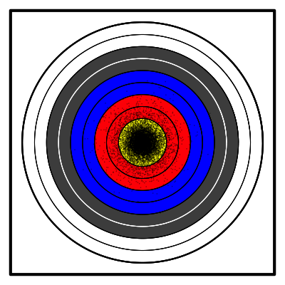

   From those many arrows, Archie has determined an accurate probability distribution (of the points scored by an arrow).

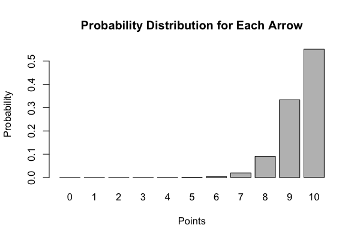

   Archie has determined her arrows’ population mean and population standard deviation.
   $$\mu=9.41$$
   $$\sigma=0.78$$

## Sampling distribution

   Each day, Archie shoots 60 arrows ($n=60$) and determines that day’s mean score. A mean of 10 would be a perfect day. We can treat each day’s mean as a random variable with its own probability distribution: a [sampling distribution](https://en.wikipedia.org/wiki/Sampling_distribution). We wish to characterize this sampling distribution. From the [central limit theorem](https://en.wikipedia.org/wiki/Central_limit_theorem), we know the sampling distribution is approximately normal; however, we need to calculate the parameters: the mean and the standard error.

### Mean of the sampling distribution

   The sampling distribution’s mean is simply equal to the population mean.
   $$\text{expected mean} = \mu$$
   - What is the sampling distribution’s mean?

### Standard error (standard deviation of sampling distribution)

   The standard error of a mean is the quotient of the population standard deviation and the square root of the sample size.
   $$\text{standard error of mean} = \frac{\sigma}{\sqrt{n}}$$
   This standard error is the standard deviation of the sampling distribution.
   - What is the standard error of the sampling distribution?

### Sample

   Today, Archie’s mean score is 9.35 points ($\bar{x} = 9.35$).

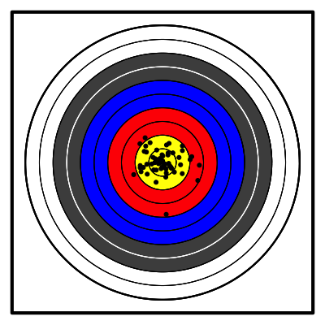

### Standard score

   Archie would like to know how well she did today. She wants you to calculate a standard score (a $z$ score). To calculate the standard score of a sample mean, you can use the following formula.
   $$z = \frac{\bar x - \mu}{\sigma/\sqrt{n}}$$
   - What is the $z$ score?

### Cumulative probability (percentile rank)

   Archie would like to know the probability that tomorrow she shoots worse than today. To estimate this, report the cumulative probability associated with the $z$-score you calculated. This can be done with a [$z$ table](https://en.wikipedia.org/wiki/Standard_normal_table#Conversion), `pnorm` function in R, `NORM.DIST` function in a spreadsheet, or with other standard normal tools.

   Remember, since we are using a $z$ score, the normal distribution parameters are mean=0 and sd=1.
   - What is the probability that Archie shoots worse tomorrow?

### Rating

   Archie would like a rating for her day’s performance. You decide to use the following scale and that if $z$ is on a boundary, Archie will be given the higher rating.

   | $z$ interval | rating |
   | --- | --- |
   | $-\infty$ to -1.51 | F |
   | -1.5 to -0.51 | D |
   | -0.5 to 0.49 | C |
   | 0.5 to 1.49 | B |
   | 1.5 to $\infty$ | A |

   - Determine Archie’s rating:

#### Solution

#### Question

6. This question provides $\mu$, $\sigma$, $n$, and $\bar{x}$. You will characterize the [sampling distribution](https://en.wikipedia.org/wiki/Sampling_distribution) by finding the [standard error](https://en.wikipedia.org/wiki/Standard_error), calculate the [standard score](https://en.wikipedia.org/wiki/Standard_score), determine the [percentile rank](https://en.wikipedia.org/wiki/Percentile_rank) (expressed as a decimal), and translate the score into a rating (see below).

### Population

   When Archie practices archery, each arrow has the same probability distribution (see [i.i.d](https://en.wikipedia.org/wiki/Independent_and_identically_distributed_random_variables)). This means her skill is constant, there is no [hot-hand effect](https://en.wikipedia.org/wiki/Hot_hand), and there is no [maturity of chances](https://en.wikipedia.org/wiki/Gambler%27s_fallacy).

   Over many months, Archie has shot ten thousand arrows (their positions are shown below as dots).

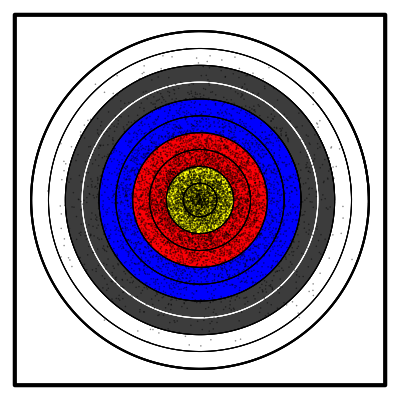

   From those many arrows, Archie has determined an accurate probability distribution (of the points scored by an arrow).

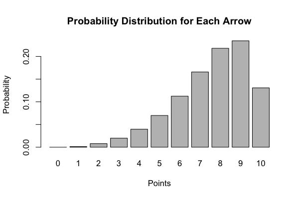

   Archie has determined her arrows’ population mean and population standard deviation.
   $$\mu=7.58$$
   $$\sigma=1.82$$

## Sampling distribution

   Each day, Archie shoots 60 arrows ($n=60$) and determines that day’s mean score. A mean of 10 would be a perfect day. We can treat each day’s mean as a random variable with its own probability distribution: a [sampling distribution](https://en.wikipedia.org/wiki/Sampling_distribution). We wish to characterize this sampling distribution. From the [central limit theorem](https://en.wikipedia.org/wiki/Central_limit_theorem), we know the sampling distribution is approximately normal; however, we need to calculate the parameters: the mean and the standard error.

### Mean of the sampling distribution

   The sampling distribution’s mean is simply equal to the population mean.
   $$\text{expected mean} = \mu$$
   - What is the sampling distribution’s mean?

### Standard error (standard deviation of sampling distribution)

   The standard error of a mean is the quotient of the population standard deviation and the square root of the sample size.
   $$\text{standard error of mean} = \frac{\sigma}{\sqrt{n}}$$
   This standard error is the standard deviation of the sampling distribution.
   - What is the standard error of the sampling distribution?

### Sample

   Today, Archie’s mean score is 8.2 points ($\bar{x} = 8.2$).

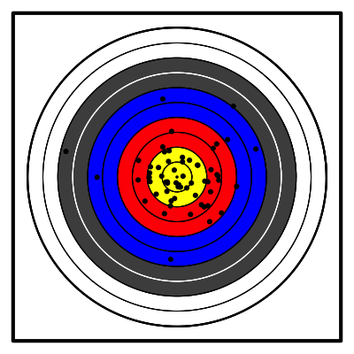

### Standard score

   Archie would like to know how well she did today. She wants you to calculate a standard score (a $z$ score). To calculate the standard score of a sample mean, you can use the following formula.
   $$z = \frac{\bar x - \mu}{\sigma/\sqrt{n}}$$
   - What is the $z$ score?

### Cumulative probability (percentile rank)

   Archie would like to know the probability that tomorrow she shoots worse than today. To estimate this, report the cumulative probability associated with the $z$-score you calculated. This can be done with a [$z$ table](https://en.wikipedia.org/wiki/Standard_normal_table#Conversion), `pnorm` function in R, `NORM.DIST` function in a spreadsheet, or with other standard normal tools.

   Remember, since we are using a $z$ score, the normal distribution parameters are mean=0 and sd=1.
   - What is the probability that Archie shoots worse tomorrow?

### Rating

   Archie would like a rating for her day’s performance. You decide to use the following scale and that if $z$ is on a boundary, Archie will be given the higher rating.

   | $z$ interval | rating |
   | --- | --- |
   | $-\infty$ to -1.51 | F |
   | -1.5 to -0.51 | D |
   | -0.5 to 0.49 | C |
   | 0.5 to 1.49 | B |
   | 1.5 to $\infty$ | A |

   - Determine Archie’s rating:

#### Solution

#### Question

7. This question provides $\mu$, $\sigma$, $n$, and $\bar{x}$. You will characterize the [sampling distribution](https://en.wikipedia.org/wiki/Sampling_distribution) by finding the [standard error](https://en.wikipedia.org/wiki/Standard_error), calculate the [standard score](https://en.wikipedia.org/wiki/Standard_score), determine the [percentile rank](https://en.wikipedia.org/wiki/Percentile_rank) (expressed as a decimal), and translate the score into a rating (see below).

### Population

   When Archie practices archery, each arrow has the same probability distribution (see [i.i.d](https://en.wikipedia.org/wiki/Independent_and_identically_distributed_random_variables)). This means her skill is constant, there is no [hot-hand effect](https://en.wikipedia.org/wiki/Hot_hand), and there is no [maturity of chances](https://en.wikipedia.org/wiki/Gambler%27s_fallacy).

   Over many months, Archie has shot ten thousand arrows (their positions are shown below as dots).

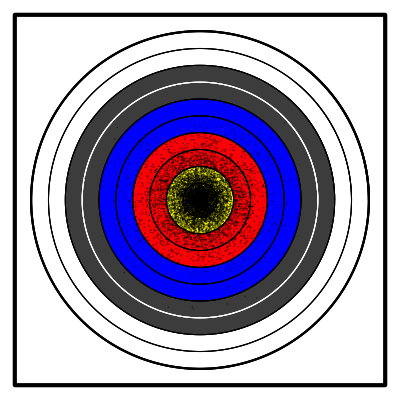

   From those many arrows, Archie has determined an accurate probability distribution (of the points scored by an arrow).

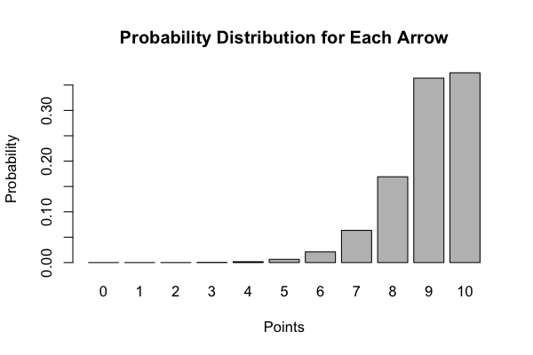

   Archie has determined her arrows’ population mean and population standard deviation.
   $$\mu=8.98$$
   $$\sigma=1.07$$

## Sampling distribution

   Each day, Archie shoots 132 arrows ($n=132$) and determines that day’s mean score. A mean of 10 would be a perfect day. We can treat each day’s mean as a random variable with its own probability distribution: a [sampling distribution](https://en.wikipedia.org/wiki/Sampling_distribution). We wish to characterize this sampling distribution. From the [central limit theorem](https://en.wikipedia.org/wiki/Central_limit_theorem), we know the sampling distribution is approximately normal; however, we need to calculate the parameters: the mean and the standard error.

### Mean of the sampling distribution

   The sampling distribution’s mean is simply equal to the population mean.
   $$\text{expected mean} = \mu$$
   - What is the sampling distribution’s mean?

### Standard error (standard deviation of sampling distribution)

   The standard error of a mean is the quotient of the population standard deviation and the square root of the sample size.
   $$\text{standard error of mean} = \frac{\sigma}{\sqrt{n}}$$
   This standard error is the standard deviation of the sampling distribution.
   - What is the standard error of the sampling distribution?

### Sample

   Today, Archie’s mean score is 9.023 points ($\bar{x} = 9.023$).

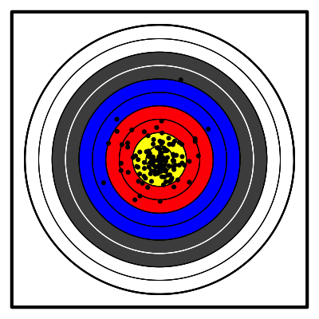

### Standard score

   Archie would like to know how well she did today. She wants you to calculate a standard score (a $z$ score). To calculate the standard score of a sample mean, you can use the following formula.
   $$z = \frac{\bar x - \mu}{\sigma/\sqrt{n}}$$
   - What is the $z$ score?

### Cumulative probability (percentile rank)

   Archie would like to know the probability that tomorrow she shoots worse than today. To estimate this, report the cumulative probability associated with the $z$-score you calculated. This can be done with a [$z$ table](https://en.wikipedia.org/wiki/Standard_normal_table#Conversion), `pnorm` function in R, `NORM.DIST` function in a spreadsheet, or with other standard normal tools.

   Remember, since we are using a $z$ score, the normal distribution parameters are mean=0 and sd=1.
   - What is the probability that Archie shoots worse tomorrow?

### Rating

   Archie would like a rating for her day’s performance. You decide to use the following scale and that if $z$ is on a boundary, Archie will be given the higher rating.

   | $z$ interval | rating |
   | --- | --- |
   | $-\infty$ to -1.51 | F |
   | -1.5 to -0.51 | D |
   | -0.5 to 0.49 | C |
   | 0.5 to 1.49 | B |
   | 1.5 to $\infty$ | A |

   - Determine Archie’s rating:

#### Solution

#### Question

8. This question provides $\mu$, $\sigma$, $n$, and $\bar{x}$. You will characterize the [sampling distribution](https://en.wikipedia.org/wiki/Sampling_distribution) by finding the [standard error](https://en.wikipedia.org/wiki/Standard_error), calculate the [standard score](https://en.wikipedia.org/wiki/Standard_score), determine the [percentile rank](https://en.wikipedia.org/wiki/Percentile_rank) (expressed as a decimal), and translate the score into a rating (see below).

### Population

   When Archie practices archery, each arrow has the same probability distribution (see [i.i.d](https://en.wikipedia.org/wiki/Independent_and_identically_distributed_random_variables)). This means her skill is constant, there is no [hot-hand effect](https://en.wikipedia.org/wiki/Hot_hand), and there is no [maturity of chances](https://en.wikipedia.org/wiki/Gambler%27s_fallacy).

   Over many months, Archie has shot ten thousand arrows (their positions are shown below as dots).

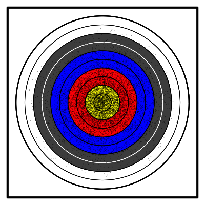

   From those many arrows, Archie has determined an accurate probability distribution (of the points scored by an arrow).

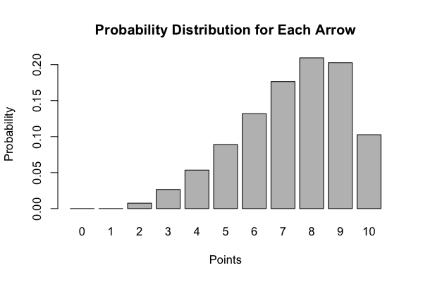

   Archie has determined her arrows’ population mean and population standard deviation.
   $$\mu=7.31$$
   $$\sigma=1.85$$

## Sampling distribution

   Each day, Archie shoots 72 arrows ($n=72$) and determines that day’s mean score. A mean of 10 would be a perfect day. We can treat each day’s mean as a random variable with its own probability distribution: a [sampling distribution](https://en.wikipedia.org/wiki/Sampling_distribution). We wish to characterize this sampling distribution. From the [central limit theorem](https://en.wikipedia.org/wiki/Central_limit_theorem), we know the sampling distribution is approximately normal; however, we need to calculate the parameters: the mean and the standard error.

### Mean of the sampling distribution

   The sampling distribution’s mean is simply equal to the population mean.
   $$\text{expected mean} = \mu$$
   - What is the sampling distribution’s mean?

### Standard error (standard deviation of sampling distribution)

   The standard error of a mean is the quotient of the population standard deviation and the square root of the sample size.
   $$\text{standard error of mean} = \frac{\sigma}{\sqrt{n}}$$
   This standard error is the standard deviation of the sampling distribution.
   - What is the standard error of the sampling distribution?

### Sample

   Today, Archie’s mean score is 7.583 points ($\bar{x} = 7.583$).

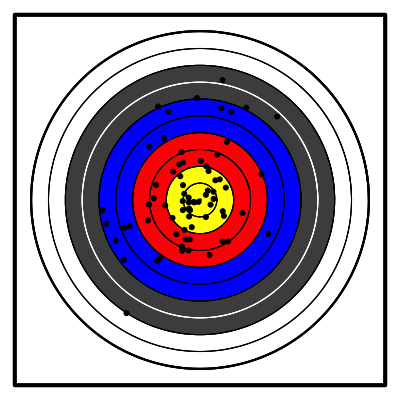

### Standard score

   Archie would like to know how well she did today. She wants you to calculate a standard score (a $z$ score). To calculate the standard score of a sample mean, you can use the following formula.
   $$z = \frac{\bar x - \mu}{\sigma/\sqrt{n}}$$
   - What is the $z$ score?

### Cumulative probability (percentile rank)

   Archie would like to know the probability that tomorrow she shoots worse than today. To estimate this, report the cumulative probability associated with the $z$-score you calculated. This can be done with a [$z$ table](https://en.wikipedia.org/wiki/Standard_normal_table#Conversion), `pnorm` function in R, `NORM.DIST` function in a spreadsheet, or with other standard normal tools.

   Remember, since we are using a $z$ score, the normal distribution parameters are mean=0 and sd=1.
   - What is the probability that Archie shoots worse tomorrow?

### Rating

   Archie would like a rating for her day’s performance. You decide to use the following scale and that if $z$ is on a boundary, Archie will be given the higher rating.

   | $z$ interval | rating |
   | --- | --- |
   | $-\infty$ to -1.51 | F |
   | -1.5 to -0.51 | D |
   | -0.5 to 0.49 | C |
   | 0.5 to 1.49 | B |
   | 1.5 to $\infty$ | A |

   - Determine Archie’s rating:

#### Solution